# PracticalMachineLearning pg

Patrick Garrabrant, CLU

August 20, 2016

## Practical Machine Learning Assignment

This is the Practical Machine Learning Assignment. We are taking data and trying to predict which set of exercises it belongs to; A, B, C, D or E. They were asked to perform barbell lifts correctly and incorrectly in 5 different ways. :

```r
library(caret)
library(rpart)

library(rattle)
```

## Data

Loading the data and removing the columns that have NAs. None of the movement columns seem to have NAs, just some columns with only a few data elements. I am also going to remove the first 7 columns as they seem to just log when the exercise took place. The data we want is the 52 columns of the various movements and the 53rd column which is the A, B, C, D, E (column is called “classe”)

```r
AllData <- read.csv("pml-training.csv", na.strings= c("NA", " ","#DIV/0!"))
dim(AllData)
```

```
## [1] 19622   160
```

```r
# Get rid of columns with NAs

K <- is.na(AllData)

TossOut <- which (colSums(K)>1)

Data <- AllData[ , -TossOut]
dim(Data)
```

```
## [1] 19622    60
```

```r
table(complete.cases(Data))
```

```
##
##  TRUE
## 19622
```

```r
ProjectData <- Data[ , -c(1:7), drop=FALSE]
dim(ProjectData)
```

```
## [1] 19622    53
```

## Split

Splitting the information into Testing and Training Data. We’ll test our models on 30% of the Data. We will then use the model we pick to forecast the 20 rows for the quiz assignment.

```r
Split<- createDataPartition(ProjectData$classe, p=0.7, list=FALSE)

TrainingProj<- ProjectData[Split, ]
TestingProj <- ProjectData[-Split, ]
```

## RPart

The first model we will test is a decision tree.

```r
Rpart<- train(classe~., method="rpart", data=TrainingProj)
print(Rpart$finalModel)
```

```
## n= 13737
##
## node), split, n, loss, yval, (yprob)
##       * denotes terminal node
##
##  1) root 13737 9831 A (0.28 0.19 0.17 0.16 0.18)
##    2) roll_belt< 130.5 12589 8692 A (0.31 0.21 0.19 0.18 0.11)
##      4) pitch_forearm< -33.95 1123    9 A (0.99 0.008 0 0 0) *
##      5) pitch_forearm>=-33.95 11466 8683 A (0.24 0.23 0.21 0.2 0.12)
##       10) magnet_dumbbell_y< 438.5 9664 6940 A (0.28 0.18 0.24 0.19 0.11)
##         20) roll_forearm< 123.5 6041 3598 A (0.4 0.18 0.19 0.17 0.061) *
##         21) roll_forearm>=123.5 3623 2420 C (0.078 0.17 0.33 0.23 0.19) *
##       11) magnet_dumbbell_y>=438.5 1802  874 B (0.033 0.51 0.04 0.23 0.18) *
##    3) roll_belt>=130.5 1148    9 E (0.0078 0 0 0 0.99) *
```

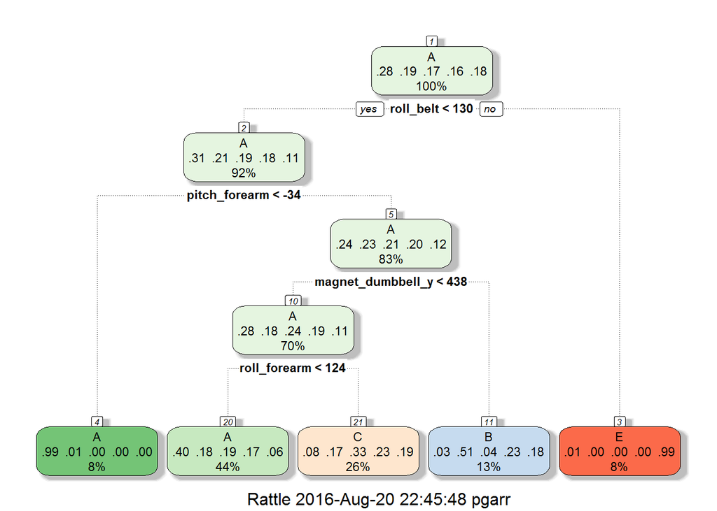

```r
fancyRpartPlot(Rpart$finalModel)
```

```r
PredictRPart <- predict(Rpart, TestingProj)

 table(PredictRPart, TestingProj$classe)
```

```
##
## PredictRPart    A    B    C    D    E
##            A 1519  479  465  426  154
##            B   28  365   37  160  159
##            C  122  295  524  378  277
##            D    0    0    0    0    0
##            E    5    0    0    0  492
```

```r
confPart<- confusionMatrix(PredictRPart, TestingProj$classe)
confPart
```

```
## Confusion Matrix and Statistics
##
##           Reference
## Prediction    A    B    C    D    E
##          A 1519  479  465  426  154
##          B   28  365   37  160  159
##          C  122  295  524  378  277
##          D    0    0    0    0    0
##          E    5    0    0    0  492
##
## Overall Statistics
##
##                Accuracy : 0.4928
##                  95% CI : (0.4799, 0.5056)
##     No Information Rate : 0.2845
##     P-Value [Acc > NIR] : < 2.2e-16
##
##                   Kappa : 0.3374
##  Mcnemar's Test P-Value : NA
##
## Statistics by Class:
##
##                      Class: A Class: B Class: C Class: D Class: E
## Sensitivity            0.9074  0.32046  0.51072   0.0000  0.45471
## Specificity            0.6381  0.91909  0.77938   1.0000  0.99896
## Pos Pred Value         0.4992  0.48732  0.32832      NaN  0.98994
## Neg Pred Value         0.9455  0.84930  0.88296   0.8362  0.89050
## Prevalence             0.2845  0.19354  0.17434   0.1638  0.18386
## Detection Rate         0.2581  0.06202  0.08904   0.0000  0.08360
## Detection Prevalence   0.5171  0.12727  0.27120   0.0000  0.08445
## Balanced Accuracy      0.7727  0.61977  0.64505   0.5000  0.72684
```

## Random Forest

We will now look at a Random Forest Model

```r
RForest<-train(classe~., method="rf", data=TrainingProj)
MRForest<-predict(RForest, newdata = TestingProj)

confMForest<- confusionMatrix(MRForest, TestingProj$classe)
confMForest
```

```
## Confusion Matrix and Statistics
##
##           Reference
## Prediction    A    B    C    D    E
##          A 1671    7    0    0    0
##          B    1 1132    9    0    0
##          C    1    0 1013    8    0
##          D    0    0    4  956    2
##          E    1    0    0    0 1080
##
## Overall Statistics
##
##                Accuracy : 0.9944
##                  95% CI : (0.9921, 0.9961)
##     No Information Rate : 0.2845
##     P-Value [Acc > NIR] : < 2.2e-16
##
##                   Kappa : 0.9929
##  Mcnemar's Test P-Value : NA
##
## Statistics by Class:
##
##                      Class: A Class: B Class: C Class: D Class: E
## Sensitivity            0.9982   0.9939   0.9873   0.9917   0.9982
## Specificity            0.9983   0.9979   0.9981   0.9988   0.9998
## Pos Pred Value         0.9958   0.9912   0.9912   0.9938   0.9991
## Neg Pred Value         0.9993   0.9985   0.9973   0.9984   0.9996
## Prevalence             0.2845   0.1935   0.1743   0.1638   0.1839
## Detection Rate         0.2839   0.1924   0.1721   0.1624   0.1835
## Detection Prevalence   0.2851   0.1941   0.1737   0.1635   0.1837
## Balanced Accuracy      0.9983   0.9959   0.9927   0.9952   0.9990
```

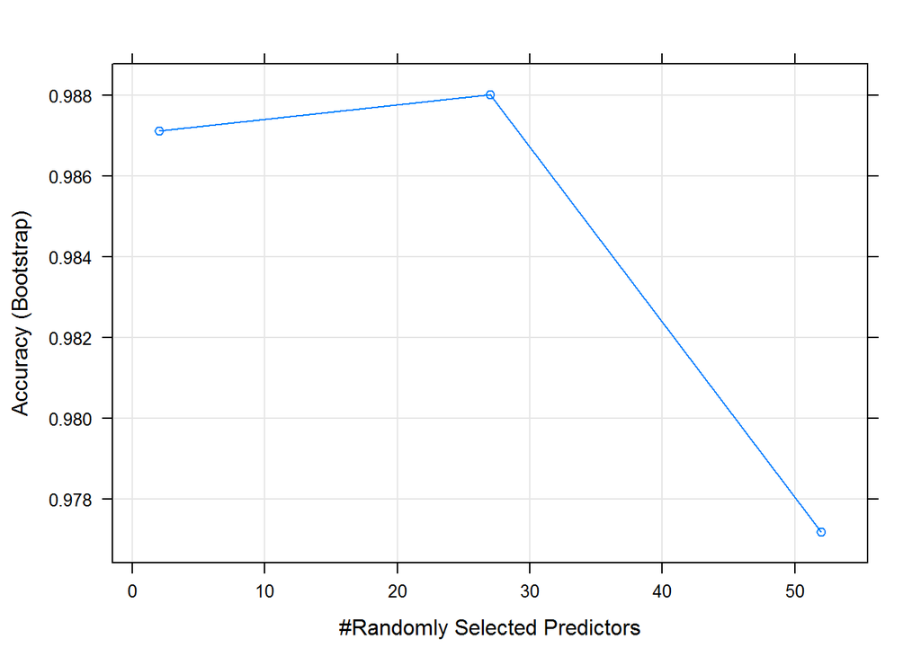

```r
plot(RForest)
```

That came out at 99% so that is looking good.

## GBM

We will now look at final model

```r
GBM<- train(classe~., data=TrainingProj, verbose=FALSE, method="gbm")
GBM$finalModel
```

```
## A gradient boosted model with multinomial loss function.
## 150 iterations were performed.
## There were 52 predictors of which 43 had non-zero influence.
```

```r
modGBM<- predict(GBM, newdata=TestingProj)

CFMgbm<- confusionMatrix(modGBM, TestingProj$classe)
CFMgbm
```

```
## Confusion Matrix and Statistics
##
##           Reference
## Prediction    A    B    C    D    E
##          A 1652   30    0    0    1
##          B   16 1069   43    2   14
##          C    3   38  974   36    5
##          D    2    1    7  921   15
##          E    1    1    2    5 1047
##
## Overall Statistics
##
##                Accuracy : 0.9623
##                  95% CI : (0.9571, 0.967)
##     No Information Rate : 0.2845
##     P-Value [Acc > NIR] : < 2.2e-16
##
##                   Kappa : 0.9523
##  Mcnemar's Test P-Value : 9.39e-07
##
## Statistics by Class:
##
##                      Class: A Class: B Class: C Class: D Class: E
## Sensitivity            0.9869   0.9385   0.9493   0.9554   0.9677
## Specificity            0.9926   0.9842   0.9831   0.9949   0.9981
## Pos Pred Value         0.9816   0.9344   0.9223   0.9736   0.9915
## Neg Pred Value         0.9948   0.9852   0.9892   0.9913   0.9928
## Prevalence             0.2845   0.1935   0.1743   0.1638   0.1839
## Detection Rate         0.2807   0.1816   0.1655   0.1565   0.1779
## Detection Prevalence   0.2860   0.1944   0.1794   0.1607   0.1794
## Balanced Accuracy      0.9897   0.9614   0.9662   0.9752   0.9829
```

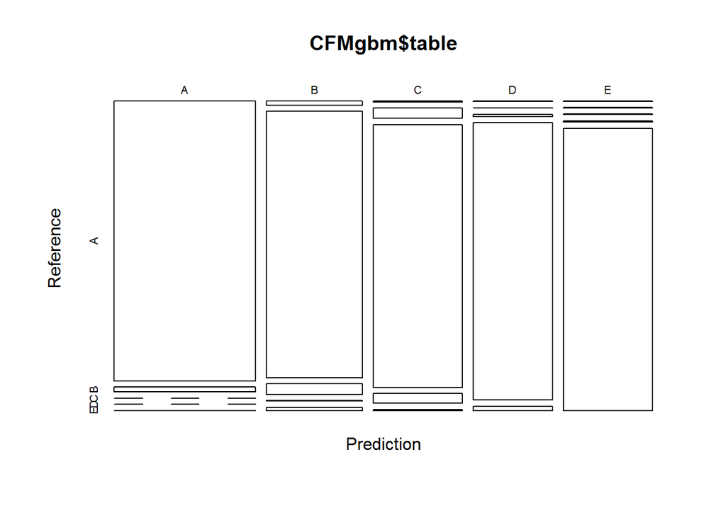

```r
plot(CFMgbm$table, col = CFMgbm$byClass)
```

This model also seems to work.

## RESULTS

Part of the assignment asks us to compare the models.

```r
Results <- data.frame(
Model= c("rpart", "RF", "GBM"),
Accuracy = rbind(confPart$overall[1], confMForest$overall[1],CFMgbm$overall[1]))
print(Results)
```

```
##   Model  Accuracy
## 1 rpart 0.4927782
## 2    RF 0.9943925
## 3   GBM 0.9622770
```

## 20 Real Tests

We will now apply the Random Forest model to the 20 data elements. I plugged these into the quiz and received a 20 out of 20 so that feels good.

```r
TEST<-read.csv("pml-testing.csv", na.strings= c("NA", " ","#DIV/0!"))
 result<- predict(RForest, TEST)
 result
```

```
##  [1] B A B A A E D B A A B C B A E E A B B B
## Levels: A B C D E
```